# Cluster Analysis

Renni Ekaputri (renniekaputri15@gmail.com)

November 12, 2019

*|Data Scientist|Business Analyst|BI Specialist|Senior Project Management Officer|Senior Project Planning|*

*|EASA Part M CAMO 145 Technical Service Engineer|Aircraft Asset Management Specialist|*

## Cognition of Clustering Analysis

For a better visualization and sensitivity analysis, on this project we used several R statistical packages:

- `Dedendextend-package {dendextend}` is a function for extending dendrogram objects. For general tree structure there is`Dendrogram {stats}`, class “dendrogram” provides general functions for handling tree-like structures. It is intended as a replacement for similar functions in hierarchical clustering and classification/regression trees, such that all of these can use the same engine for plotting or cutting trees. Hierarchical cluster analysis `hclust {stats}` on a set of dissimilarities and methods for analyzing cluster. Furthermore,`stats-package {stats}`, this package contains functions for statistical calculations and random number generation.
- `Knitr-package {knitr}`takes an input file, extracts the R code in it according to a list of patterns, evaluates the code and writes the output in another file.
- `Gplot-package {gplots}`is a vignette summarises the various formats that grid drawing functions take.
- `Corrplot-package (corrplot}`is a graphical display of a correlation matrix, confidence interval. It also contains some algorithms to do matrix reordering. In addition, corrplot is good at details, including choosing color, text labels, color labels, layout, etc.

`Iris` for flower species, `repub` for presidential vote, `animals` for animal clustering, and microarrray `gene for train and test` expression, those 4 datasets will be used on this project.

```r
library("DT")
iris <- datasets::iris
datatable(iris, options=list(pageLength = 4, scrollX=T))
```

|  | Sepal.Length | Sepal.Width | Petal.Length | Petal.Width | Species |
| --- | --- | --- | --- | --- | --- |
| 1 | 5.1 | 3.5 | 1.4 | 0.2 | setosa |
| 2 | 4.9 | 3 | 1.4 | 0.2 | setosa |
| 3 | 4.7 | 3.2 | 1.3 | 0.2 | setosa |
| 4 | 4.6 | 3.1 | 1.5 | 0.2 | setosa |
| 5 | 5 | 3.6 | 1.4 | 0.2 | setosa |
| 6 | 5.4 | 3.9 | 1.7 | 0.4 | setosa |
| 7 | 4.6 | 3.4 | 1.4 | 0.3 | setosa |
| 8 | 5 | 3.4 | 1.5 | 0.2 | setosa |
| 9 | 4.4 | 2.9 | 1.4 | 0.2 | setosa |
| 10 | 4.9 | 3.1 | 1.5 | 0.1 | setosa |

[output cut: 140 more lines]

```r
library("DT")
votes.repub <- cluster::votes.repub
datatable(votes.repub, options=list(pageLength = 4, scrollX=T))
```

|  | X1856 | X1860 | X1864 | X1868 | X1872 | X1876 | X1880 | X1884 | X1888 | X1892 | X1896 | X1900 | X1904 | X1908 | X1912 | X1916 | X1920 | X1924 | X1928 | X1932 | X1936 | X1940 | X1944 | X1948 | X1952 | X1956 | X1960 | X1964 | X1968 | … |
| --- | --- | --- | --- | --- | --- | --- | --- | --- | --- | --- | --- | --- | --- | --- | --- | --- | --- | --- | --- | --- | --- | --- | --- | --- | --- | --- | --- | --- | --- | --- |
| Alabama |  |  |  | 51.44 | 53.19 | 40.02 | 36.98 | 38.44 | 32.28 | 3.95 | 28.13 | 34.67 | 20.65 | 24.38 | 8.26 | 21.97 | 30.98 | 27.01 | 48.49 | 14.15 | 12.82 | 14.34 | 18.2 | 19.04 | 35.02 | 39.39 | 41.75 | 69.5 | 14 | … |
| Alaska |  |  |  |  |  |  |  |  |  |  |  |  |  |  |  |  |  |  |  |  |  |  |  |  |  |  | 50.94 | 34.1 | 45.3 | … |
| Arizona |  |  |  |  |  |  |  |  |  |  |  |  |  |  | 12.74 | 35.37 | 55.41 | 41.26 | 57.57 | 30.53 | 26.93 | 36.01 | 40.9 | 43.82 | 58.35 | 60.99 | 55.52 | 50.4 | 54.8 | … |
| Arkansas |  |  |  | 53.73 | 52.17 | 39.88 | 39.55 | 40.5 | 38.07 | 32.01 | 25.11 | 35.04 | 40.25 | 37.31 | 19.73 | 28.01 | 38.73 | 29.28 | 39.33 | 12.91 | 17.86 | 20.87 | 29.84 | 21.02 | 43.76 | 45.82 | 43.06 | 43.9 | 30.8 | … |
| California | 18.77 | 32.96 | 58.63 | 50.24 | 56.38 | 50.88 | 48.92 | 52.08 | 49.95 | 43.76 | 49.13 | 54.48 | 61.9 | 55.46 | 0.58 | 46.26 | 66.24 | 57.21 | 64.7 | 37.4 | 31.7 | 41.35 | 42.99 | 47.14 | 56.39 | 55.4 | 50.1 | 40.9 | 47.8 | … |
| Colorado |  |  |  |  |  |  | 51.28 | 54.39 | 55.31 | 41.13 | 13.84 | 42.04 | 55.27 | 46.88 | 21.88 | 34.75 | 59.32 | 57.02 | 64.72 | 41.43 | 37.09 | 50.92 | 53.21 | 46.52 | 60.27 | 59.49 | 54.63 | 38.7 | 50.5 | … |
| Connecticut | 53.18 | 53.86 | 51.38 | 51.54 | 52.25 | 48.34 | 50.52 | 48.01 | 48.44 | 46.8 | 63.24 | 56.94 | 58.13 | 59.43 | 35.88 | 49.8 | 62.72 | 61.54 | 53.63 | 48.54 | 40.35 | 46.3 | 46.94 | 49.55 | 55.7 | 63.73 | 46.27 | 32.2 | 44.3 | … |
| Delaware | 2.11 | 23.71 | 48.2 | 40.98 | 50.99 | 44.55 | 47.86 | 42.75 | 43.55 | 48.55 | 52.94 | 53.65 | 54.04 | 52.09 | 32.85 | 50.2 | 55.71 | 57.71 | 65.03 | 50.55 | 43.43 | 45.05 | 45.27 | 50.04 | 51.75 | 55.09 | 49 | 39.1 | 45.1 | … |
| Florida |  |  |  |  | 53.52 | 50.99 | 45.83 | 46.82 | 39.94 |  | 24.3 | 19.03 | 21.15 | 21.58 | 8.25 | 18.08 | 30.79 | 28.06 | 56.83 | 25.04 | 23.85 | 25.99 | 29.68 | 33.63 | 55.01 | 57.2 | 51.51 | 48.9 | 40.5 | … |
| Georgia |  |  |  | 35.72 | 43.77 | 27.94 | 34.33 | 33.84 | 28.33 | 21.8 | 36.82 | 28.56 | 18.32 | 31.4 | 4.27 | 7.07 | 28.57 | 18.19 | 43.37 | 7.77 | 12.6 | 14.84 | 18.25 | 18.31 | 30.34 | 33.22 | 37.44 | 54.1 | 30.4 | … |

[output cut: 40 more lines]

```r
library("DT")
animals <- cluster::animals
datatable(animals, options=list(pageLength = 4, scrollX=T))
```

|  | war | fly | ver | end | gro | hai |
| --- | --- | --- | --- | --- | --- | --- |
| ant | 1 | 1 | 1 | 1 | 2 | 1 |
| bee | 1 | 2 | 1 | 1 | 2 | 2 |
| cat | 2 | 1 | 2 | 1 | 1 | 2 |
| cpl | 1 | 1 | 1 | 1 | 1 | 2 |
| chi | 2 | 1 | 2 | 2 | 2 | 2 |
| cow | 2 | 1 | 2 | 1 | 2 | 2 |
| duc | 2 | 2 | 2 | 1 | 2 | 1 |
| eag | 2 | 2 | 2 | 2 | 1 | 1 |
| ele | 2 | 1 | 2 | 2 | 2 | 1 |
| fly | 1 | 2 | 1 | 1 | 1 | 1 |

[output cut: 10 more lines]

## Study Cases

### Flower Species

```r
library(dendextend)
library(knitr)
knitr::opts_chunk$set(
   cache = TRUE,
   dpi = 75,
   fig.width = 6, fig.height = 6,
   tidy = FALSE)
```

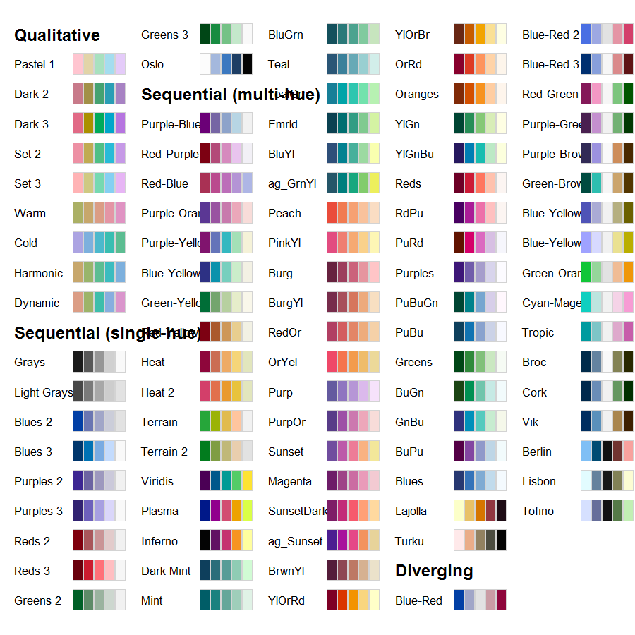

```r
iris <- datasets::iris
iris2 <- iris[,-5]
species_labels <- iris[,5]
library(colorspace) # get nice colors
hcl_palettes(plot = TRUE)
```

```r
(palette = "Dark 3")
```

```
## [1] "Dark 3"
```

```r
species_col <- rev(rainbow_hcl(3))[as.numeric(species_labels)]
```

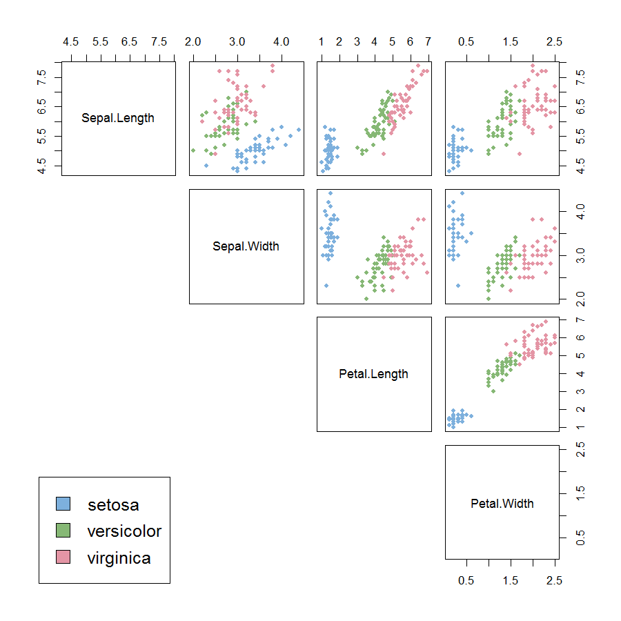

```r
# Plot a SPLOM:
pairs(iris2, col = species_col,
      lower.panel = NULL,
       cex.labels=1.1, pch=20, cex = 1.2)

# Add a legend
par(xpd = TRUE)
legend(x = 0.01, y = 0.2, cex = 1,
   legend = as.character(levels(species_labels)),
    fill = unique(species_col))
```

```r
par(xpd = NA)
```

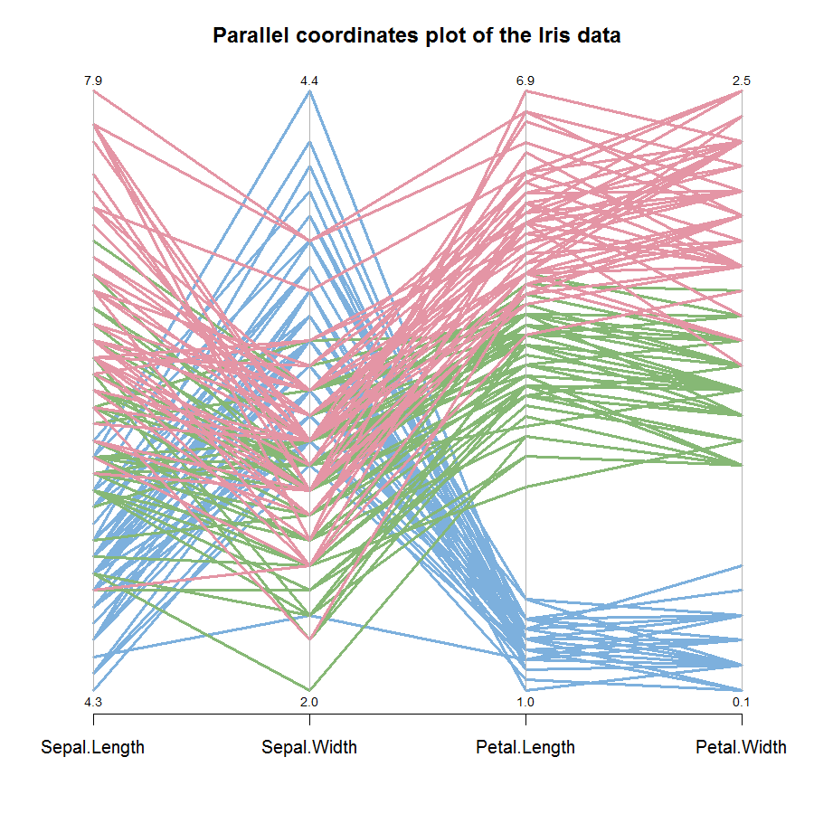

```r
par(las = 1, mar = c(4.5, 3, 3, 2) + 0.1, cex = .8)
MASS::parcoord(iris2, col = species_col, var.label = TRUE, lwd = 2)

# Add Title
title("Parallel coordinates plot of the Iris data")
# Add a legend
par(xpd = TRUE)
legend(x = 1.75, y = -.25, cex = 1,
   legend = as.character(levels(species_labels)),
    fill = unique(species_col), horiz = TRUE)
```

```r
par(xpd = NA)
```

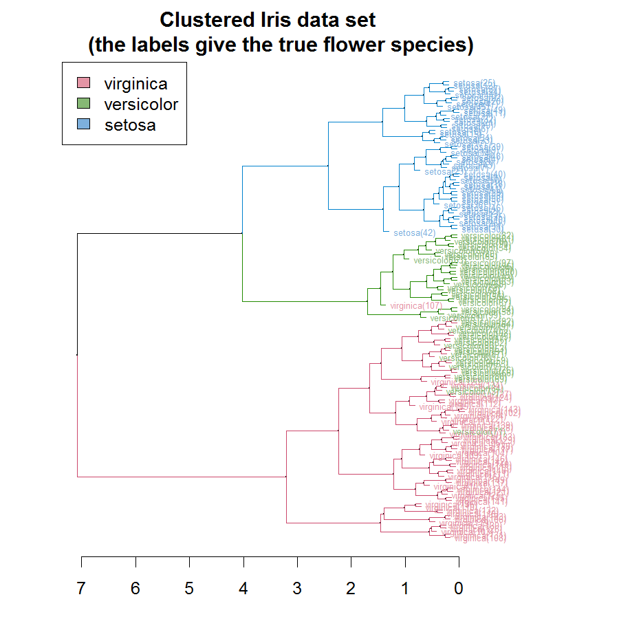

```r
d_iris <- dist(iris2) # method="man" # is a bit better
hc_iris <- hclust(d_iris, method = "complete")
iris_species <- rev(levels(iris[,5]))

library(dendextend)
dend <- as.dendrogram(hc_iris)
# order it the closest we can to the order of the observations:
dend <- rotate(dend, 1:150)

# Color the branches based on the clusters:
dend <- color_branches(dend, k=3) #, groupLabels=iris_species)

# Manually match the labels, as much as possible, to the real classification of the flowers:
labels_colors(dend) <-
   rainbow_hcl(3)[sort_levels_values(
      as.numeric(iris[,5])[order.dendrogram(dend)]
   )]

# We shall add the flower type to the labels:
labels(dend) <- paste(as.character(iris[,5])[order.dendrogram(dend)],
                           "(",labels(dend),")",
                           sep = "")
# We hang the dendrogram a bit:
dend <- hang.dendrogram(dend,hang_height=0.1)
# reduce the size of the labels:
# dend <- assign_values_to_leaves_nodePar(dend, 0.5, "lab.cex")
dend <- set(dend, "labels_cex", 0.5)
# And plot:
par(mar = c(3,3,3,7))
plot(dend,
     main = "Clustered Iris data set
     (the labels give the true flower species)",
     horiz =  TRUE,  nodePar = list(cex = .007))
legend("topleft", legend = iris_species, fill = rainbow_hcl(3))
```

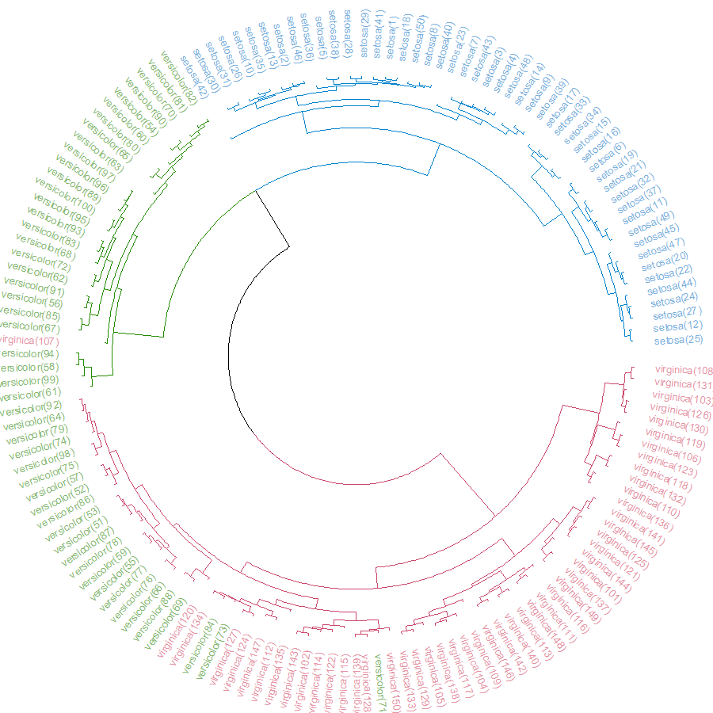

```r
par(mar = rep(0,4))
circlize_dendrogram(dend)
```

```r
some_col_func <- function(n) rev(colorspace::heat_hcl(n, c = c(80, 30), l = c(30, 90), power = c(1/5, 1.5)))
```

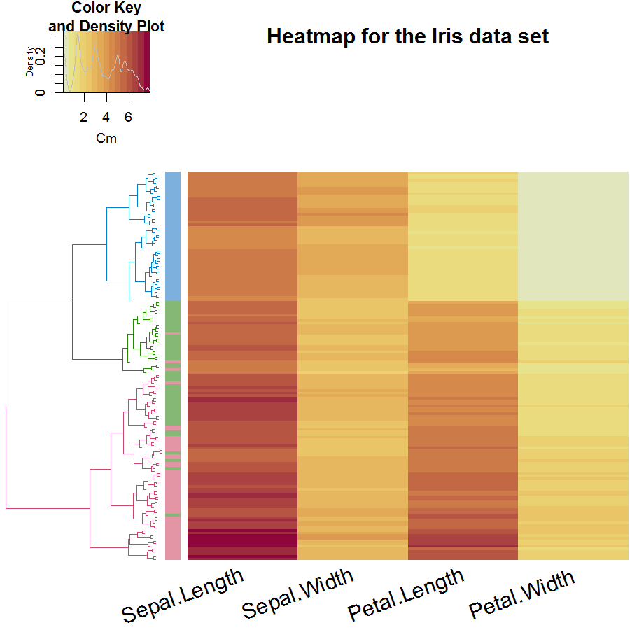

```r
library(gplots)
gplots::heatmap.2(as.matrix(iris2),
          main = "Heatmap for the Iris data set",
          srtCol = 20,
          dendrogram = "row",
          Rowv = dend,
          Colv = "NA", # this to make sure the columns are not ordered
          trace="none",
          margins =c(5,0.1),
          key.xlab = "Cm",
          denscol = "grey",
          density.info = "density",
          RowSideColors = rev(labels_colors(dend)), # to add nice colored strips
          col = some_col_func
         )
```

```r
hclust_methods <- c("ward.D", "single", "complete", "average", "mcquitty",
        "median", "centroid", "ward.D2")
iris_dendlist <- dendlist()
for(i in seq_along(hclust_methods)) {
   hc_iris <- hclust(d_iris, method = hclust_methods[i])
   iris_dendlist <- dendlist(iris_dendlist, as.dendrogram(hc_iris))
}
names(iris_dendlist) <- hclust_methods
iris_dendlist
```

```
## $ward.D
## 'dendrogram' with 2 branches and 150 members total, at height 199.6205
##
## $single
## 'dendrogram' with 2 branches and 150 members total, at height 1.640122
##
## $complete
## 'dendrogram' with 2 branches and 150 members total, at height 7.085196
##
## $average
## 'dendrogram' with 2 branches and 150 members total, at height 4.062683
##
## $mcquitty
## 'dendrogram' with 2 branches and 150 members total, at height 4.497283
##
## $median
## 'dendrogram' with 2 branches and 150 members total, at height 2.82744
##
## $centroid
## 'dendrogram' with 2 branches and 150 members total, at height 2.994307
##
## $ward.D2
## 'dendrogram' with 2 branches and 150 members total, at height 32.44761
##
## attr(,"class")
## [1] "dendlist"
```

```r
iris_dendlist_cor <- cor.dendlist(iris_dendlist)
iris_dendlist_cor
```

```
##             ward.D    single  complete   average  mcquitty    median
## ward.D   1.0000000 0.9836838 0.5774013 0.9841333 0.9641103 0.9451815
## single   0.9836838 1.0000000 0.5665529 0.9681156 0.9329029 0.9444723
## complete 0.5774013 0.5665529 1.0000000 0.6195121 0.6107473 0.6889092
## average  0.9841333 0.9681156 0.6195121 1.0000000 0.9828015 0.9449422
## mcquitty 0.9641103 0.9329029 0.6107473 0.9828015 1.0000000 0.9203374
## median   0.9451815 0.9444723 0.6889092 0.9449422 0.9203374 1.0000000
## centroid 0.9809088 0.9903934 0.5870062 0.9801444 0.9499123 0.9403569
## ward.D2  0.9911648 0.9682507 0.6096286 0.9895131 0.9829977 0.9445832
##           centroid   ward.D2
## ward.D   0.9809088 0.9911648
## single   0.9903934 0.9682507
## complete 0.5870062 0.6096286
## average  0.9801444 0.9895131
## mcquitty 0.9499123 0.9829977
## median   0.9403569 0.9445832
## centroid 1.0000000 0.9737886
## ward.D2  0.9737886 1.0000000
```

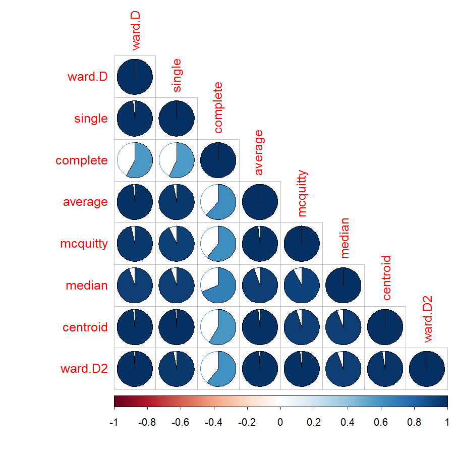

```r
corrplot::corrplot(iris_dendlist_cor, "pie", "lower")
```

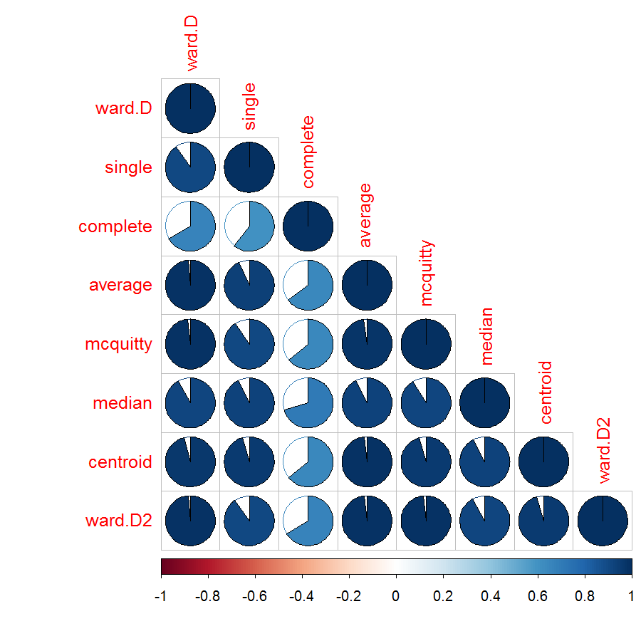

```r
iris_dendlist_cor_spearman <- cor.dendlist(iris_dendlist, method_coef = "spearman")
corrplot::corrplot(iris_dendlist_cor_spearman, "pie", "lower")
```

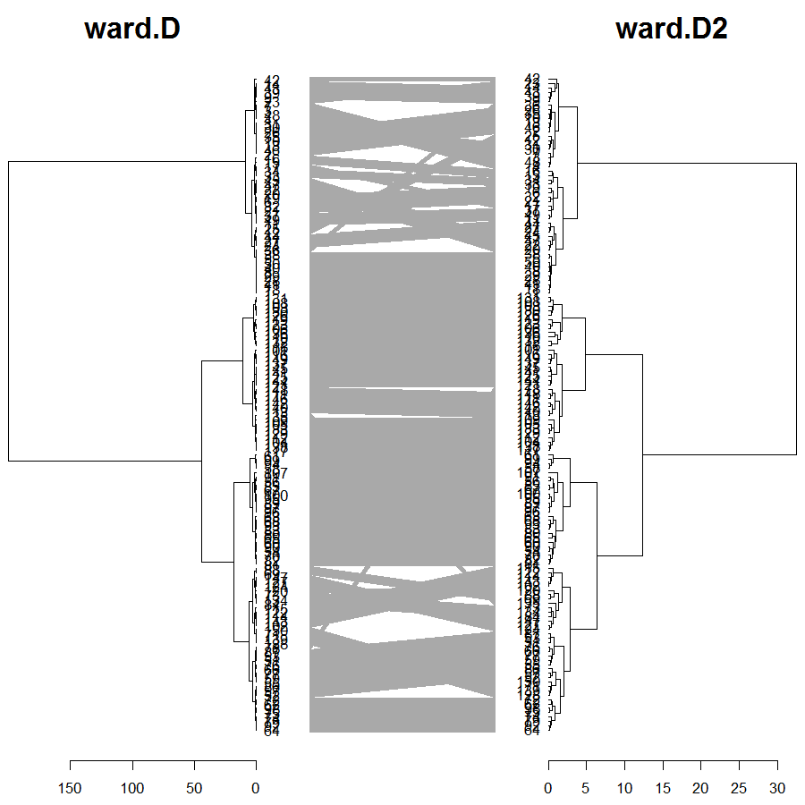

```r
iris_dendlist %>% dendlist(which = c(1,8)) %>% ladderize %>%
   set("branches_k_color", k=3) %>%
  untangle(method = "step1side", k_seq = 3:20) %>%
  set("clear_branches") %>% #otherwise the single lines are not black, since they retain the previous color from the branches_k_color.
   tanglegram(faster = TRUE) # (common_subtrees_color_branches = TRUE)
```

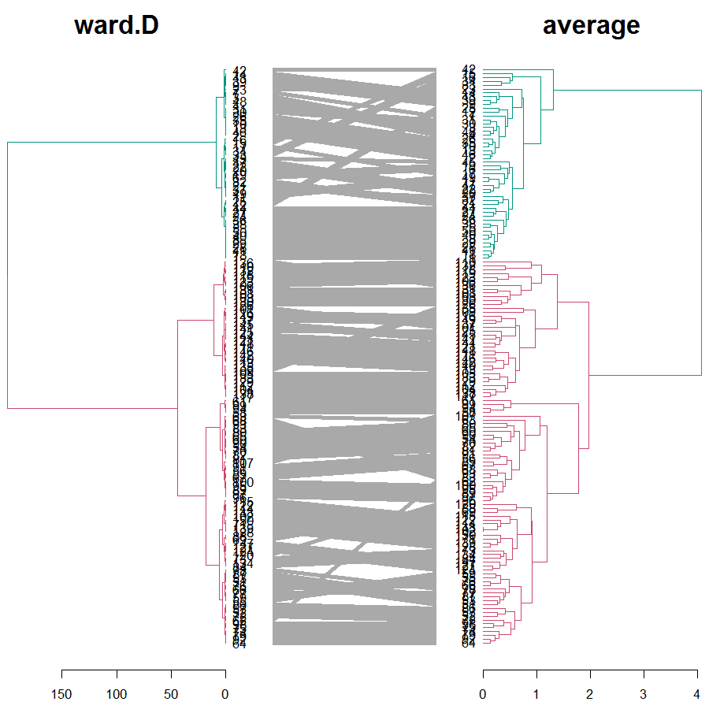

```r
iris_dendlist %>% dendlist(which = c(1,4)) %>% ladderize %>%
   set("branches_k_color", k=2) %>%
untangle(method = "step1side", k_seq = 3:20) %>%
tanglegram(faster = TRUE) # (common_subtrees_color_branches = TRUE)
```

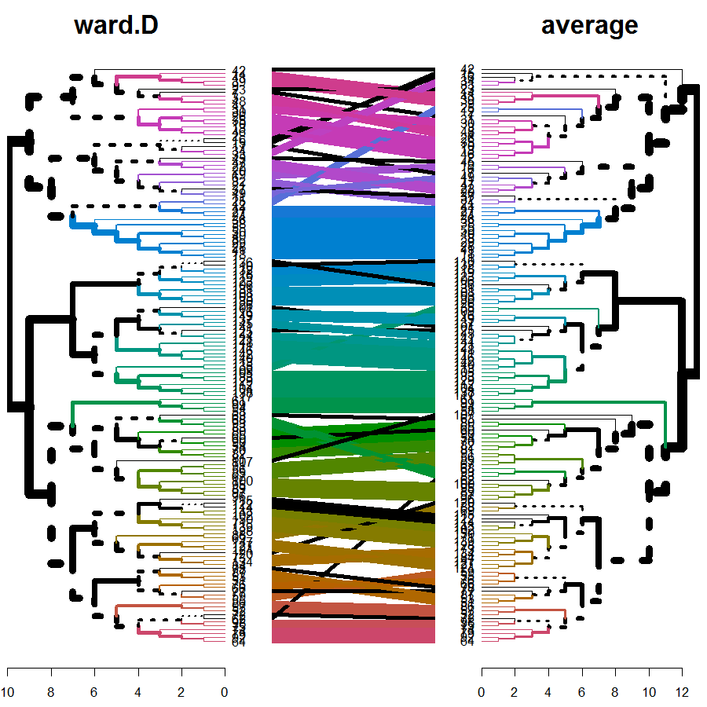

```r
iris_dendlist %>% dendlist(which = c(1,4)) %>% ladderize %>%
untangle(method = "step1side", k_seq = 3:20) %>%
   set("rank_branches") %>%
   tanglegram(common_subtrees_color_branches = TRUE)
```

```r
length(unique(common_subtrees_clusters(iris_dendlist[[1]], iris_dendlist[[4]]))[-1])
```

```
## [1] 39
```

```r
# -1 at the end is because we are ignoring the "0" subtree, which indicates leaves that are singletons.
```

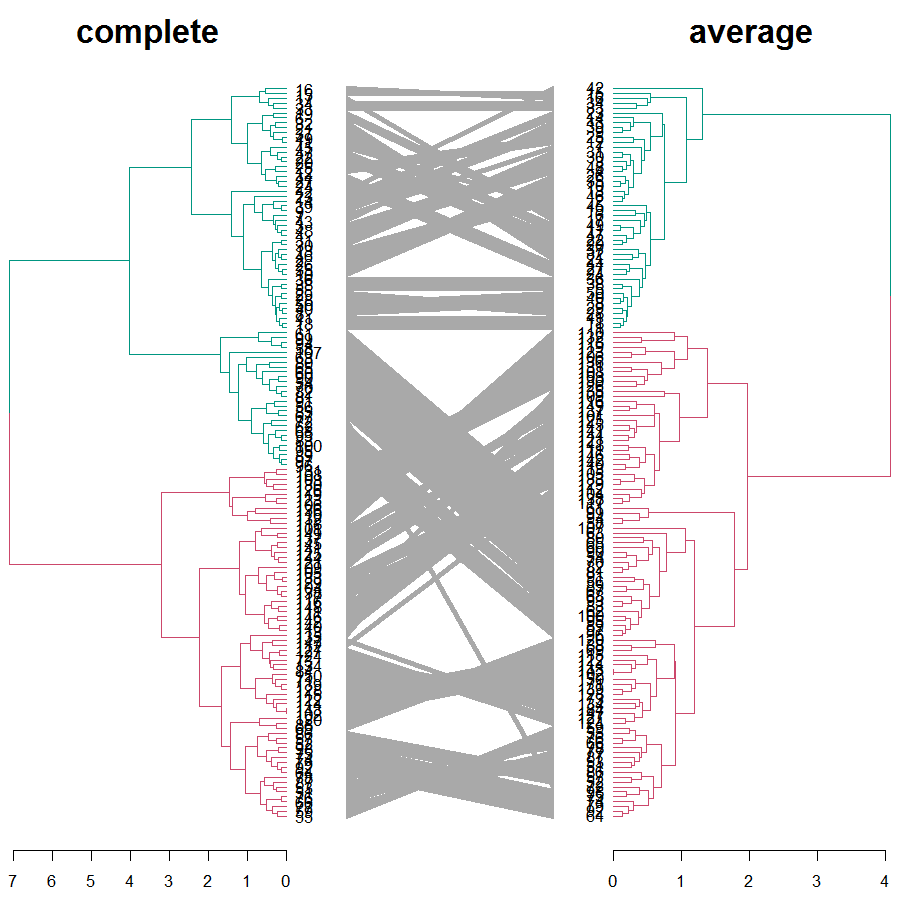

```r
iris_dendlist %>% dendlist(which = c(3,4)) %>% ladderize %>%
   untangle(method = "step1side", k_seq = 2:6) %>%
   set("branches_k_color", k=2) %>%
   tanglegram(faster = TRUE) # (common_subtrees_color_branches = TRUE)
```

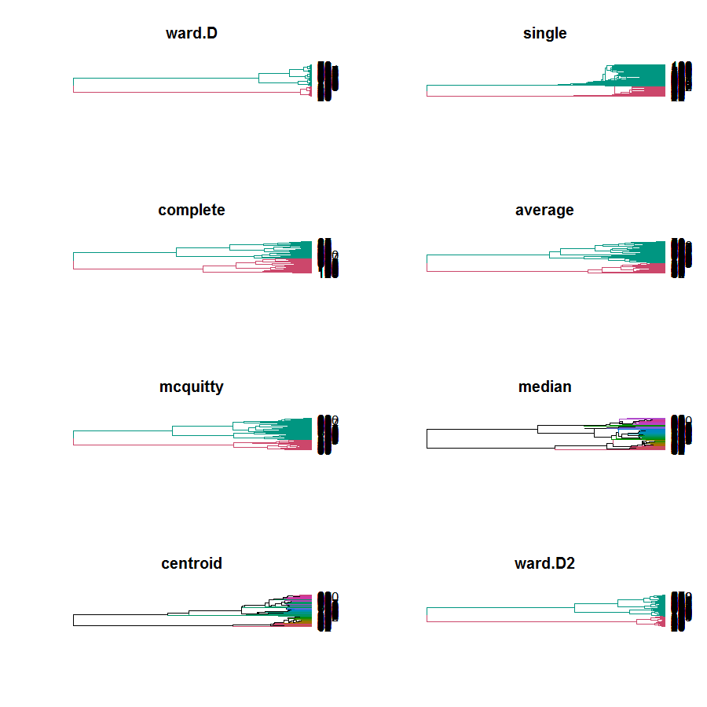

```r
par(mfrow = c(4,2))
for(i in 1:8) {
   iris_dendlist[[i]] %>% set("branches_k_color", k=2) %>% plot(axes = FALSE, horiz = TRUE)
   title(names(iris_dendlist)[i])
}
```

```r
iris_dendlist_cor2 <- cor.dendlist(iris_dendlist, method = "common")
iris_dendlist_cor2
```

```
##             ward.D    single  complete   average  mcquitty    median
## ward.D   1.0000000 0.7324415 0.8595318 0.8461538 0.8361204 0.7458194
## single   0.7324415 1.0000000 0.7324415 0.7491639 0.7458194 0.7591973
## complete 0.8595318 0.7324415 1.0000000 0.8060201 0.7993311 0.7491639
## average  0.8461538 0.7491639 0.8060201 1.0000000 0.8494983 0.7892977
## mcquitty 0.8361204 0.7458194 0.7993311 0.8494983 1.0000000 0.7859532
## median   0.7458194 0.7591973 0.7491639 0.7892977 0.7859532 1.0000000
## centroid 0.7324415 0.7625418 0.7290970 0.7725753 0.7759197 0.8528428
## ward.D2  0.8795987 0.7324415 0.8294314 0.8294314 0.8294314 0.7558528
##           centroid   ward.D2
## ward.D   0.7324415 0.8795987
## single   0.7625418 0.7324415
## complete 0.7290970 0.8294314
## average  0.7725753 0.8294314
## mcquitty 0.7759197 0.8294314
## median   0.8528428 0.7558528
## centroid 1.0000000 0.7357860
## ward.D2  0.7357860 1.0000000
```

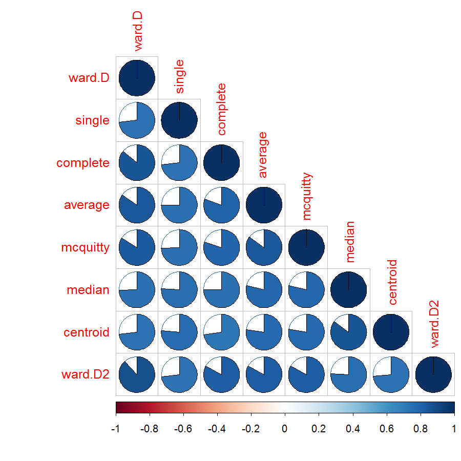

```r
corrplot::corrplot(iris_dendlist_cor2, "pie", "lower")
```

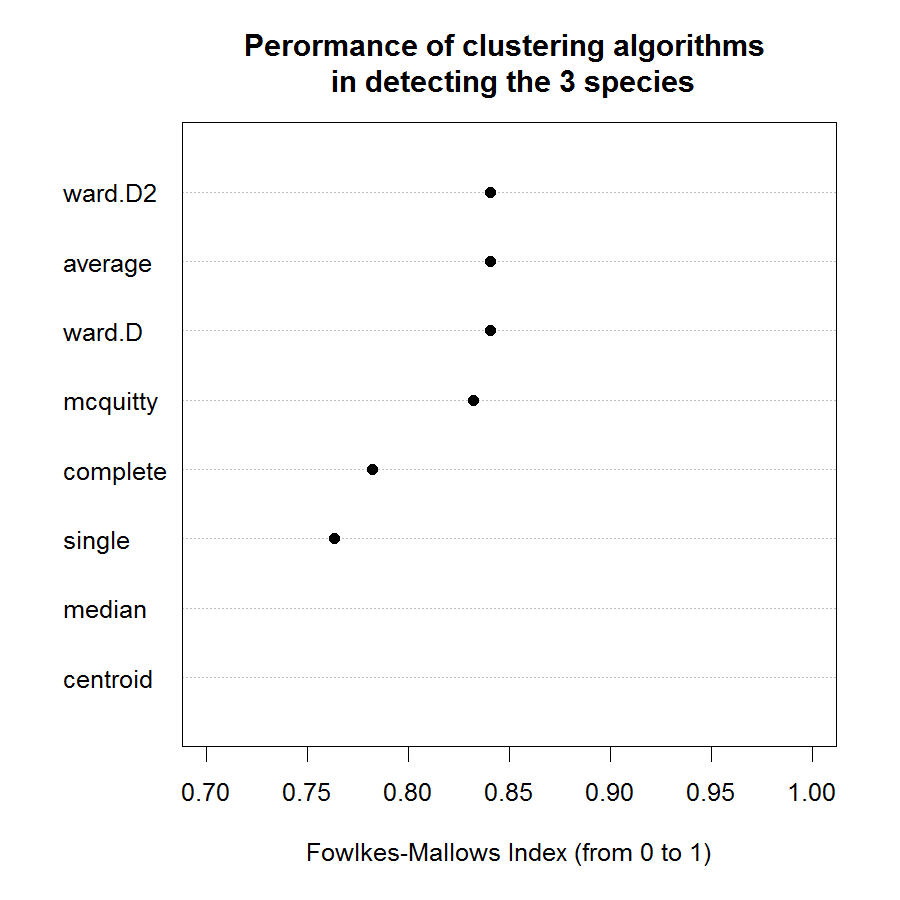

```r
get_ordered_3_clusters <- function(dend) {
   cutree(dend, k = 3)[order.dendrogram(dend)]
}

dend_3_clusters <- lapply(iris_dendlist, get_ordered_3_clusters)

compare_clusters_to_iris <- function(clus) {FM_index(clus, rep(1:3, each = 50), assume_sorted_vectors = TRUE)}

clusters_performance <- sapply(dend_3_clusters, compare_clusters_to_iris)
dotchart(sort(clusters_performance), xlim = c(0.7,1),
         xlab = "Fowlkes-Mallows Index (from 0 to 1)",
         main = "Perormance of clustering algorithms \n in detecting the 3 species",
         pch = 19)
```

### Gene

```r
train <- dendextend::khan$train
test <- dendextend::khan$test
d_train <- train %>% dist %>% hclust %>% as.dendrogram
d_test <- test %>% dist %>% hclust %>% as.dendrogram
d_train_test <- dendlist(train = d_train, test = d_test)
d_train_test %>% cor.dendlist
```

```
##           train      test
## train 1.0000000 0.5708019
## test  0.5708019 1.0000000
```

```r
d_train_test %>% cor.dendlist(method_coef = "spearman")
```

```
##           train      test
## train 1.0000000 0.4971936
## test  0.4971936 1.0000000
```

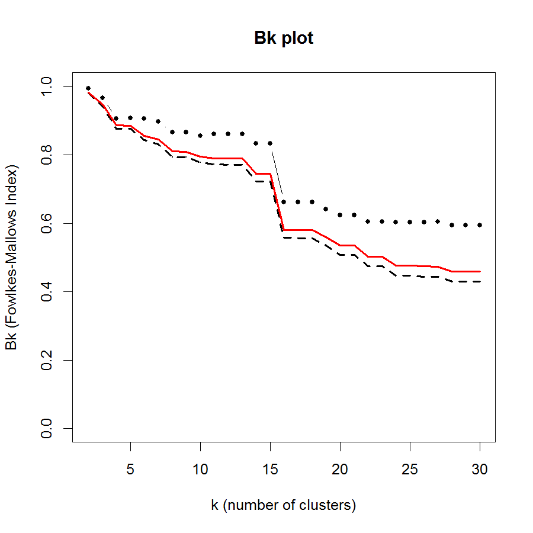

```r
Bk_plot(d_train, d_test, k = 2:30, xlim = c(2,30))
```

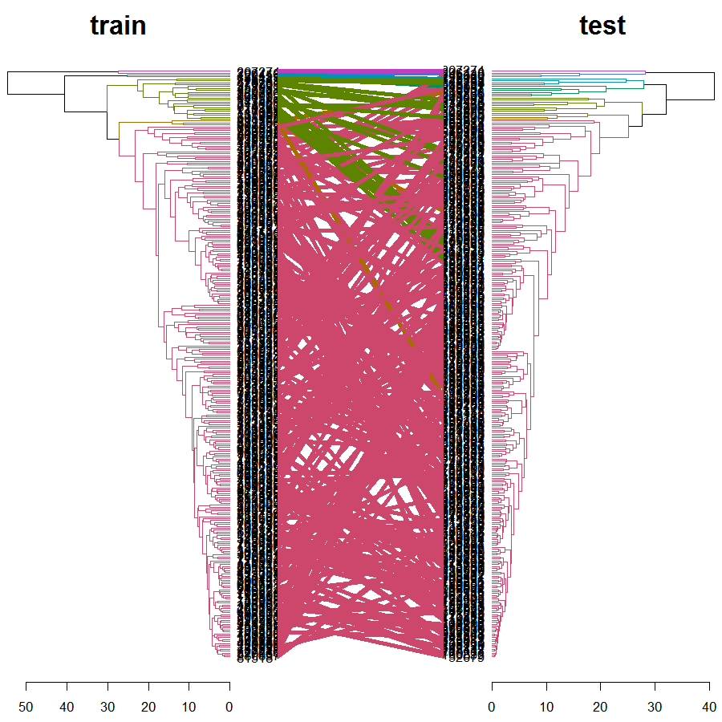

```r
pre_tang_d_train_test <- d_train_test %>% ladderize %>% # untangle %>%
   set("branches_k_color", k = 7)
train_branches_colors <- get_leaves_branches_col(pre_tang_d_train_test$train)
pre_tang_d_train_test %>% tanglegram(fast = TRUE, color_lines = train_branches_colors)
```